# DeepLearning para estimación de Clear A

Patricio Said

20 de diciembre de 2018

| Versión | Fecha | Cambios |
| --- | --- | --- |
| v1.0 | 21/12/18 | Modificando Grid Search |

# Introducción

El siguiente código desarrolla una RNA para el cálculo de rendimiento de Clear A. Se realizará una primera búsqueda general por medio de un grid y ramdom search con el objetivo de encontrar rangos de algunos parámetros:

- Funciónes de activación.
- Arquitectura, cantidad de capas ocultas y nodos.
- Variables de importancia y cuáles se podrían descartar.
- Tasa de aprendizaje.
- Cantidad de epocas, iteraciones, y conjuntos de ejemplos.
- Otros parámetros: L1, L2, anneling rate, momentum, epsilon, rho, etc…

# Paso 1: Importar Datos

Se importan los datos con la funcion `readxl()`

```r
library(readxl)
datos <- read_excel("~/Documentos/rnin_git/rnin/datos/DATOS2.xlsx")
# Imprimir dimensión
dim(datos)
```

```
## [1] 3038  233
```

Se seleccionaron algunas variables de interés

```r
datos <- datos[,c(           "cod_id_FUNDO"
                        ,"COD_Z_CPINO"                              #2 cod zona prod 1 a 10
                        ,"DSC_ESQUEMA"                              #2 Esquema
                        ,"TIPO_TIERRA"                              #2

                        ,"N24_ALTURA_MEDIA"                         #1
                        ,"N24_ALT_MEDIA_DOMINA"
                        ,"N24_IND_MEDIO_SITIO"                      #2
                        ,"N24_DAP_MEDIO"                            #1
                        ,"N24_DAP_MEDIO_DOMINA"
                        ,"N24_ALT_MEDIA_PODA"                       #1
                        ,"N24_COEF_VARIACION_DIAMETRO"              #2
                        ,"N24_DENSIDAD_PODADOS"                     #1
                        ,"N24_DENSIDAD_ACTUAL"                      #1

                        ,"PROP_PODADA"                              #1
                                       ,"OT"
                        ,"EDAD_OT"                                  #1
                        ,"EDAD_COSECHA"                             #2
                        ,"ANOS_PROYECTADOS"
                            ,"PLI"
                                               ###### SALIDAS
                        ,"V_R_INTR_CLEAR_A"                         #?
                        ,"V_R_CLASE_CLEAR_A"                        #?
                        ,"V_R_INTR_CLEAR_A_pp"                      #1 Clear A %
                        ,"V_R_CLASE_CLEAR_A_pp"                     #? ver si es igual...
                        ,"VOLUROD_SF_CLEAR_A_pp"                    #comparar resultados
                        ,"VOLUROD_SF_CLEAR_A"                       # volur clear a

                        ,"V_R_INTR_CLEAR_B"                         #1 Clear B
                        ,"V_R_INTR_CLEAR_B_pp"                      #1 Clear b %
                        ,"VOLUROD_SF_CLEAR_B"                       # volu
                        ,"VOLUROD_SF_CLEAR_B_pp"                    # volu

                        ,"V_R_INTR_IND"                             #1 IND
                        ,"V_R_INTR_IND_pp"                          #1 IND %
                        ,"VOLUROD_SF_IND"                           # volu ind
                        ,"VOLUROD_SF_IND_pp"                        #


                            ,"V_R_INTR_PULP"                            # PULP
                        ,"V_R_INTR_PULP_pp"                         # pulp %
                        ,"VOLUROD_SF_PULP"                          # pulp volurod
                        ,"VOLUROD_SF_PULP_pp"

                            ,"suma_de_pp"                               # suma de %
                        ,"VOL_TOTAL"                                # Vol total
                        ,"area"                                     # area
                        ,"REND_REAL_TOTAL"                          # REND
                        ,"REND_T_VOLUR"                             # rend volu
                        ,"REND_CLEAR_A_REAL"
                        ,"REND_CLEAR_B_REAL"
                        ,"REND_IND_REAL"
                        ,"REND_PULP_REAL"

                        ) ]
#Imprimir dimensión
dim(datos)
```

```
## [1] 3038   46
```

# Paso 2: Limpiar los datos

Se cambiaron nombres de las columnas:

```r
#CAMBIAR DE NOMBRE ALGUNAS VARIABLES
names(datos) <- gsub("N24_ALTURA_MEDIA", "ALTURA_MEDIA" , names(datos))
names(datos) <- gsub("N24_DAP_MEDIO", "DAP_MEDIO" , names(datos))
names(datos) <- gsub("N24_DENSIDAD_ACTUAL", "DENSIDAD" , names(datos))
names(datos) <- gsub("N24_IND_MEDIO_SITIO", "IMS" , names(datos))
names(datos) <- gsub("N24_ALT_MEDIA_PODA", "ALT_MEDIA_PODA" , names(datos))
names(datos) <- gsub("N24_DENSIDAD_PODADOS", "DENSIDAD_PODADOS" , names(datos))
#names(datos) <- gsub("EDAD_OT", "EDAD_INVENTARIO" , names(datos))
names(datos) <- gsub("TIPO_TIERRA", "DSC_SUELO" , names(datos))
names(datos) <- gsub("N24_ALT_MEDIA_DOMINA", "ALT_MEDIA_DOMINANTE" , names(datos))
names(datos) <- gsub("DAP_MEDIO_DOMINA", "DAP_MEDIO_DOMINANTE" , names(datos))
names(datos) <- gsub("DSC_ESQUEMA", "ESQUEMA" , names(datos))
```

## Columna Esquema

La columna `ESQUEMA` no se encuentra “estandarizada” (presenta diferentes nombres para una misma clase)

```r
#Imprimir las clases que posee la ESQUEMA
unique(datos$ESQUEMA)
```

```
##  [1] NA                   "EXTENSIVO CON PODA" "MULTIPROPOSITO 1"
##  [4] "INTENSIVO 1"        "PULPABLE"           "EXTENSIVO"
##  [7] "MULTIPROPOSITO 2"   "INTENSIVO"          "INTENSIVO 2"
## [10] "SIN INFORMACION"
```

```r
#Cambiando los nombres
datos$ESQUEMA[datos$ESQUEMA == "INTENSIVO 2"]<- "INTENSIVO"
datos$ESQUEMA[datos$ESQUEMA == "INTENSIVO 1"]<- "INTENSIVO"
datos$ESQUEMA[datos$ESQUEMA == "MULTIPROPOSITO 2"]<- "MULTIPROPOSITO"
datos$ESQUEMA[datos$ESQUEMA == "MULTIPROPOSITO 1"]<- "MULTIPROPOSITO"
datos$ESQUEMA[datos$ESQUEMA == "EXTENSIVO CON PODA"]<- "MULTIPROPOSITO"
datos$ESQUEMA[datos$ESQUEMA == "PULPABLE"]<- "PULPABLE"
datos$ESQUEMA[datos$ESQUEMA == "EXTENSIVO"]<- "EXTENSIVO"
#Imprimir las clases despues del cambio de nombre
unique(datos$ESQUEMA)
```

```
## [1] NA                "MULTIPROPOSITO"  "INTENSIVO"       "PULPABLE"
## [5] "EXTENSIVO"       "SIN INFORMACION"
```

## Borrar datos faltantes

Se borrarán las observaciones (filas) que presentan NAs en las columnas que se utilizarán en el modelo. Función `drop_na()` del paquete `tidyr`.

### Borrar NA’s en DAP

Borrado de NA’s en la columna de `DAP_MEDIO`, observando la cantidad de registros eliminados

```r
library(tidyr)
summary(datos$DAP_MEDIO)
```

```
##    Min. 1st Qu.  Median    Mean 3rd Qu.    Max.    NA's
##    3.40   23.90   29.10   29.03   34.30   56.70     978
```

```r
# Imprimir la cantidad de NA's
sum(is.na(datos$DAP_MEDIO))
```

```
## [1] 978
```

```r
datos <- drop_na(datos, ALTURA_MEDIA)
# Imprimir la cantidad de NA's despues del filtrado
sum(is.na(datos$DAP_MEDIO))
```

```
## [1] 0
```

## Borrando NA’s en otras columnas

```r
datos <- drop_na(datos, VOL_TOTAL)
datos <- drop_na(datos, DSC_SUELO)
datos <- drop_na(datos, COD_Z_CPINO)
#datos1 <- drop_na(datos1, PLI) # Filtrar en caso de uso de PLI

#IMPRIMIR dimensión de datos
dim(datos)
```

```
## [1] 2030   46
```

## Filtrado de variables

Se filtran variables según los alcances del proyecto.

```r
datos <- filter(datos, datos$ALTURA_MEDIA >= 15 )
datos <- filter(datos, datos$EDAD_OT >= 15 )
datos <- filter(datos, datos$ANOS_PROYECTADOS <6 )
datos <- filter(datos, datos$VOL_TOTAL >= 1000 )
datos <- filter(datos, ( datos$ESQUEMA != "PULPABLE") |
                   (datos$ESQUEMA == "PULPABLE" & datos$DENSIDAD_PODADOS == 0
                    & datos$V_R_INTR_CLEAR_A < 20))
datos <- filter(datos, datos$area >= 5 )
```

## Calculando nuevas variables

Se calculan: el Area basal, y sección normal con la función `mutate` Se crea una nueva columna con la variable `SECCION_NORMAL` para el càlculo del `AREA_BASAL`.  
Fórmula del área basal:

$$Area \; Basal = Densidad *\pi * \left ( \frac{DAP }{200}\right )^{2}$$

```r
datos <- mutate(datos, SECCION_NORMAL= pi*( (DAP_MEDIO/100)^2 )/4 )
#datos <- datos[,!colnames(datos)=="AREA_BASAL"] #(elimina Area Basal)
datos <- mutate(datos, AREA_BASAL = SECCION_NORMAL * DENSIDAD)
datos <- mutate(datos, CLEAR_pp = V_R_INTR_CLEAR_A_pp + V_R_INTR_CLEAR_B_pp)
```

# Paso 3: Exploración

Paquetes `tidyr`, `knitr` y `kableExtra` se usaron para construir gráficas con resúmenes.

```r
# Esta parte calcula los min max etc de las variables seleccionadas
# De salida se obtiene un vector
resumen <- datos %>%
  select( ALTURA_MEDIA , DAP_MEDIO , DENSIDAD , IMS , EDAD_OT) %>%
    rename_all( funs(
        stringr::str_replace_all(., "_", ".") )) %>%
    summarise_each(funs( min = min,
                       mean = mean,
                       max = max,
                       sd = sd)) %>%
    round(. ,1)

# Como la salida es un vector este se utiliza tidyr para cambiar la forma
resumen_f<- resumen %>%
  gather(stat, val) %>%
  separate(stat, into = c("var", "stat"), sep = "_") %>%
  spread(stat, val) %>%
  select(var, min, mean, max , sd) %>%
  rename("Variables" = var , "Mínimo" = min ,
         "Media" = mean , "Máximo" = max , "Desv. Estandar" =sd )

# Al salir el dataframe fijarse en el orden de las variables

#Cambiar nombres para renderizar
variables <- c("Altura Media", "DAP Medio" , "Densidad" , "Edad en Inventario",
               "Índice de Sitio")
resumen_f$Variables <- variables

#función para renderizar la tabla en formato HTML
kable(resumen_f) %>%
  kable_styling()
```

| Variables | Mínimo | Media | Máximo | Desv. Estandar |
| --- | --- | --- | --- | --- |
| Altura Media | 15.0 | 27.1 | 40.3 | 4.5 |
| DAP Medio | 15.6 | 31.2 | 48.0 | 6.2 |
| Densidad | 206.0 | 568.3 | 1669.0 | 247.6 |
| Edad en Inventario | 15.0 | 20.4 | 37.0 | 3.0 |
| Índice de Sitio | 14.4 | 28.5 | 36.0 | 3.2 |

# Paso 4: Preprocesamiento

El conjunto de datos se debe procesar para prepararlos antes de entrar al modelo.

## Variables categóricas a factor

La variable `Zona de Crecimiento` describe la zona por medio de números, pero debe trabajarse como variable categórica, por ende, debe transformarse a una tipo factor.

- Las variables categóricas son:
  - Zona de crecimiento
  - Esquema de manejo
  - Tipo de suelo
  - PLI **(ver si incluir)**

```r
datos$COD_Z_CPINO <- factor(datos$COD_Z_CPINO)
datos$ESQUEMA <- factor(datos$ESQUEMA)
datos$DSC_SUELO   <- factor(datos$DSC_SUELO)
```

## Transformando a Binarios

En las RNA’s las entradas categóricas deben trabajarse con variables **dummies**.

Se trabaja con el paquete `caret` y la función `dummyVars`

```r
library(caret)
```

```r
#se guardó info sobre ID y OT ( en todo caso innecesario)
cod_id_FUNDO <- datos$cod_id_FUNDO
datos <- subset( datos, select = - c(cod_id_FUNDO, OT) )
dmy <- dummyVars(" ~ .", data = datos)
trsf <- data.frame(predict(dmy, newdata = datos))
#Imprimir un head de las primeras 5 columnas
print(head(trsf[1:5]))
```

```
##   COD_Z_CPINO.1 COD_Z_CPINO.2 COD_Z_CPINO.3 COD_Z_CPINO.4 COD_Z_CPINO.5
## 1             0             0             0             0             0
## 2             0             0             0             0             0
## 3             0             0             0             0             0
## 4             0             0             0             0             0
## 5             0             0             0             0             0
## 6             0             0             0             0             0
```

El dataframe `trsf` posee las variables transformadas a variables binarias.

# Paso 5: Construcción de la Red

## Conectar H2O

Se traspasan los datos al cluster de H2O

```r
datos_h2o <- as.h2o(trsf)
```

## Partición

Para entrenar una red que presente un mejor rendimiento, los datos se dividieron en tres partes, con el fin de no seleccionar un modelo sobreajustado.

```r
splits <- h2o.splitFrame(datos_h2o , ratios = c(0.70 , 0.15 ), seed= 1234)
train <- h2o.assign(splits[[1]] , key= "train")
valid <- h2o.assign(splits[[2]] , key = "valid")
test <-  h2o.assign(splits[[3]] , key = "test")
```

## Selección de variables de entrada y salida

```r
print(variables_entradas)
```

```
##  [1] "COD_Z_CPINO.1"              "COD_Z_CPINO.2"
##  [3] "COD_Z_CPINO.3"              "COD_Z_CPINO.4"
##  [5] "COD_Z_CPINO.5"              "COD_Z_CPINO.6"
##  [7] "COD_Z_CPINO.7"              "COD_Z_CPINO.8"
##  [9] "COD_Z_CPINO.9"              "COD_Z_CPINO.10"
## [11] "ESQUEMA.EXTENSIVO"          "ESQUEMA.INTENSIVO"
## [13] "ESQUEMA.MULTIPROPOSITO"     "ESQUEMA.PULPABLE"
## [15] "DSC_SUELO.ALUVIALES"        "DSC_SUELO.ARCILLOSO"
## [17] "DSC_SUELO.ARENAS"           "DSC_SUELO.GRANITICOS"
## [19] "DSC_SUELO.METAMORFICOS"     "DSC_SUELO.SECANO"
## [21] "DSC_SUELO.SEDIMENTO.MARINO" "DSC_SUELO.TRUMAOS"
## [23] "ALTURA_MEDIA"               "ALT_MEDIA_DOMINANTE"
## [25] "IMS"                        "DAP_MEDIO"
## [27] "DAP_MEDIO_DOMINANTE"        "ALT_MEDIA_PODA"
## [29] "DENSIDAD_PODADOS"           "DENSIDAD"
## [31] "PROP_PODADA"                "PLI"
## [33] "AREA_BASAL"
```

## Especificar Hiperparámetros

Se utilizó la función `h2o.grid()` para realizar una busqueda aleatoria o Random Grid Search (RGS) RGS es una opción más rapida para construir modelos con diferentes combinaciones de hiperparámetro. Se desea encontrar una combinación de hipermarámetros (idealmente) optima que maximice el rendimiento del modelo.

### Funciones de Activación

- `Rectifier` : función por defecto. Es la más rapida y la más versatil. Sin embargo, puede conducir a la inestabilidad y tiende a ser de menor precisión.
- `Tanh` : La tangente hiperbólica es una variante escalada y desplazada de la función de activación sigmoide. Puede tomar valores de -1 a 1 y se centra alrededor de 0. Tanh necesita más potencia de cálculo que, por ejemplo, La función `rectifier`.
- `Maxout` : Es una función de activación que es el máximo de las entradas. Es computacionalmente bastante exigente pero puede producir modelos de alta precisión.
- `...WithDropout` : cuando se especifica abandono, se entrena un subconjunto aleatorio de la red y se promedian los pesos de todas las subredes. Funciona junto con el parámetro hidden_dropout_ratios, que controla la cantidad de neuronas de capa que se eliminan aleatoriamente para cada capa oculta. Los índices de abandono ocultos son útiles para evitar el sobreajuste.

### Penalidades

- `L1` : Deja que solo los pesos fuertes sobrevivan.
- `L2` : Previene que lo pesos se vulvan muy altos.
- `Rho` : Ayuda en la actualización de los pesos.
- `epsilon` : Evita atascarse en un minimo local.

```r
hyper_params <- list(
                activation=c("Rectifier" , "Tanh" , "Maxout"),
                hidden = list( c(20), c(20,20), c(300, 300) ,c(128,128,128) , c(64,64,64,64) ),
               #input_dropout_ratio =  c(0, 0.05, 0.1,0.2), # 0.1 or .2 sugerido , mejora generalizacion
            #   adaptive_rate = TRUE,
              #  rho = c(0.95),
               # epsilon = c(1e-10),
              #  rate = c(0.01, 0.05,0.1,0.005),
               # rate_annealing = 1e-06,
              ##  rate_decay = c( 0.3 ,0.4 ,0.1,0.05) ,
               # momentum_start = 0,
               # momentum_ramp = c(1e+06,1e+04,1e+05),
                #momentum_stable = c(0),
               # nesterov_accelerated_gradient = TRUE,
               # hidden_dropout_ratios = NULL,
                 #l1 = 1e-5,
                # l2 =1e-5,
              #  loss =   "Quantile" ,
               # distribution = "AUTO",
             #nfolds = c(4),    # para crossvalidation
  #overwrite_with_best_model = T,
  epochs = c( 10,20,50)
  #train_samples_per_iteration = c(40, 100 , 200,-2,-1)
)
```

### Search Criteria

```r
search_criteria <- list(
                  strategy = "RandomDiscrete",
                  stopping_tolerance = 0.001 ,
                  max_runtime_secs = 5000,
                  max_models = 10000 ,
                  stopping_rounds = 1000,
                  stopping_metric = "MSE"

                )
```

```r
randomSearch <- h2o.grid(
  algorithm = "deeplearning",
  grid_id = "CLEAR_A_V13",
  training_frame = train,
  validation_frame = valid,
  x = variables_entradas,
  y = respuesta ,
# nfolds = 4,    # para crossvalidation
 # overwrite_with_best_model = F,
 # epochs = 300,
 # train_samples_per_iteration = -2 , # 0: one epoch, -1: all available data (e.g., replicated  training data), -2: automatic
  hyper_params = hyper_params,
  search_criteria = search_criteria
)
```

### SALIDA MODELO

```r
dl_salida_grid <- h2o.getGrid( grid_id = "CLEAR_A_V13", sort_by = "mse" , decreasing = F)
summary(dl_salida_grid)
```

```
## H2O Grid Details
## ================
##
## Grid ID: CLEAR_A_V13
## Used hyper parameters:
##   -  activation
##   -  epochs
##   -  hidden
## Number of models: 45
## Number of failed models: 0
##
## Hyper-Parameter Search Summary: ordered by increasing mse
##   activation epochs           hidden            model_ids
## 1       Tanh   50.0       [300, 300] CLEAR_A_V13_model_25
## 2       Tanh   20.0  [128, 128, 128] CLEAR_A_V13_model_10
## 3  Rectifier   50.0  [128, 128, 128] CLEAR_A_V13_model_15
## 4     Maxout   20.0       [300, 300]  CLEAR_A_V13_model_4
## 5     Maxout   50.0 [64, 64, 64, 64] CLEAR_A_V13_model_19
##                  mse
## 1 263.40673819617786
## 2 282.24266354905774
## 3  292.9283981616494
## 4   294.628325966359
## 5 297.38904199792296
##
## ---
##    activation epochs          hidden            model_ids
## 40     Maxout   20.0 [128, 128, 128]  CLEAR_A_V13_model_8
## 41       Tanh   10.0            [20]  CLEAR_A_V13_model_2
## 42     Maxout   10.0            [20] CLEAR_A_V13_model_21
## 43  Rectifier   50.0            [20] CLEAR_A_V13_model_13
## 44     Maxout   50.0            [20] CLEAR_A_V13_model_32
## 45  Rectifier   20.0            [20] CLEAR_A_V13_model_33
##                   mse
## 40 450.57126997130297
## 41  452.9761393813161
## 42  462.3664038396906
## 43  472.0477201661785
## 44  472.1757041880177
## 45 473.15335569214864
```

[output cut: 41 more lines]

```
##   -  CLEAR_A_V13_model_31
##   -  CLEAR_A_V13_model_30
##   -  CLEAR_A_V13_model_45
##   -  CLEAR_A_V13_model_34
##   -  CLEAR_A_V13_model_24
##   -  CLEAR_A_V13_model_36
##   -  CLEAR_A_V13_model_16
##   -  CLEAR_A_V13_model_8
##   -  CLEAR_A_V13_model_2
##   -  CLEAR_A_V13_model_21
##   -  CLEAR_A_V13_model_13
##   -  CLEAR_A_V13_model_32
##   -  CLEAR_A_V13_model_33
##
## Number of failed models: 0
```

```r
best_model<- h2o.getModel(dl_salida_grid@model_ids[[1]])
summary(best_model)
```

```
## Model Details:
## ==============
##
## H2ORegressionModel: deeplearning
## Model Key:  CLEAR_A_V13_model_25
## Status of Neuron Layers: predicting REND_CLEAR_A_REAL, regression, gaussian distribution, Quadratic loss, 100.501 weights/biases, 1,2 MB, 33.404 training samples, mini-batch size 1
##   layer units   type dropout       l1       l2 mean_rate rate_rms momentum
## 1     1    32  Input  0.00 %       NA       NA        NA       NA       NA
## 2     2   300   Tanh  0.00 % 0.000000 0.000000  0.037831 0.035182 0.000000
## 3     3   300   Tanh  0.00 % 0.000000 0.000000  0.581264 0.335451 0.000000
## 4     4     1 Linear      NA 0.000000 0.000000  0.003255 0.001827 0.000000
##   mean_weight weight_rms mean_bias bias_rms
## 1          NA         NA        NA       NA
## 2    0.000872   0.093277 -0.003091 0.076126
## 3   -0.000063   0.062034 -0.003350 0.093651
## 4    0.001818   0.039311  0.100298 0.000000
##
## H2ORegressionMetrics: deeplearning
## ** Reported on training data. **
## ** Metrics reported on full training frame **
##
## MSE:  201.3546
## RMSE:  14.18995
## MAE:  9.966702
## RMSLE:  NaN
## Mean Residual Deviance :  201.3546
##
##
## H2ORegressionMetrics: deeplearning
## ** Reported on validation data. **
## ** Metrics reported on full validation frame **
##
## MSE:  263.4067
## RMSE:  16.22981
## MAE:  11.34973
## RMSLE:  NaN
## Mean Residual Deviance :  263.4067
##
##
##
```

[output cut: 37 more lines]

```
##              variable relative_importance scaled_importance percentage
## 1      ALT_MEDIA_PODA            1.000000          1.000000   0.054610
## 2                 PLI            0.862704          0.862704   0.047112
## 3           DAP_MEDIO            0.683966          0.683966   0.037351
## 4    DENSIDAD_PODADOS            0.668629          0.668629   0.036514
## 5 DAP_MEDIO_DOMINANTE            0.631590          0.631590   0.034491
##
## ---
##                  variable relative_importance scaled_importance percentage
## 27          COD_Z_CPINO.7            0.491120          0.491120   0.026820
## 28          COD_Z_CPINO.9            0.488323          0.488323   0.026667
## 29       DSC_SUELO.SECANO            0.481278          0.481278   0.026283
## 30 DSC_SUELO.METAMORFICOS            0.476799          0.476799   0.026038
## 31          COD_Z_CPINO.6            0.443067          0.443067   0.024196
## 32      DSC_SUELO.TRUMAOS            0.426290          0.426290   0.023280
```

```r
plot(best_model)
print( h2o.performance(best_model, test))
```

```
## H2ORegressionMetrics: deeplearning
##
## MSE:  503.8284
## RMSE:  22.44612
## MAE:  16.34489
## RMSLE:  NaN
## Mean Residual Deviance :  503.8284
```

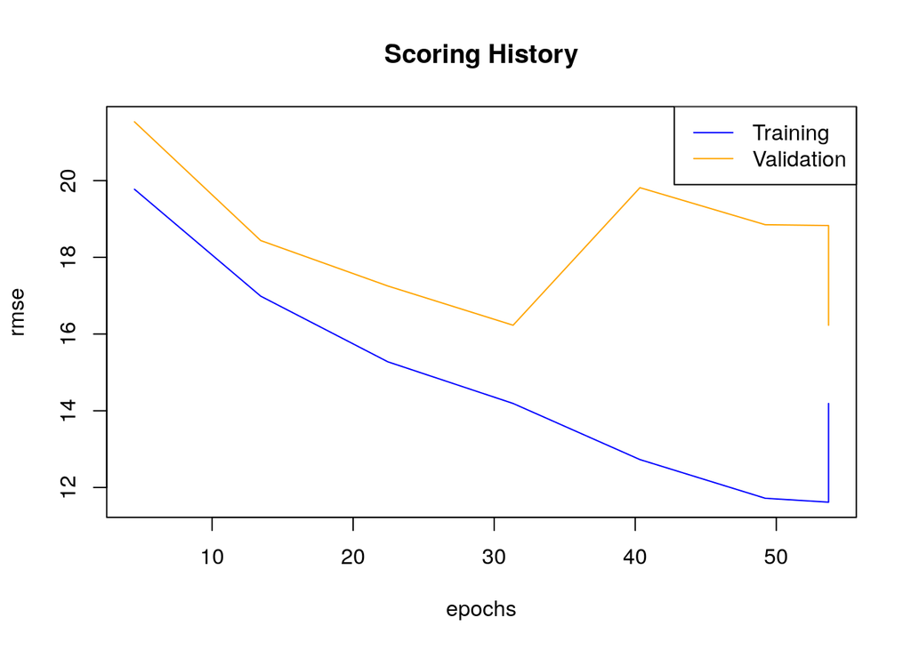

```r
plot(h2o.getModel(dl_salida_grid@model_ids[[1]]))
```

## Errores

### MSE

```r
mse <- function( obs , pred ){
  return( (1/length(obs))*(sum((obs - pred)^2)))
}

mae <- function( obs, pred ){
  return( (1/length(obs))*sum(abs(obs - pred)))
}

rmse <- function( obs , pred ){
  return( sqrt(mse(obs,pred)))
}
rmsep <- function( obs , pred ){
  return( (100/mean(obs)) * sqrt(mse(obs,pred)))
}

mape <- function( obs, pred){
  return((100/length(obs))*sum(abs((obs - pred)/obs)))
}
r2 <- function ( obs, pred){
  num = sum((pred- mean(obs))^2)
  den = sum((obs- mean(obs))^2)
  return(num/den)
}
maxABE <- function ( obs, pred){
  return (max(abs(obs - pred)))
}
```

```r
 tabla_error_nombres <- c( "MSE_TRAIN",  "RMSE_TRAIN", "RMSE%_TRAIN" , "MAE_TRAIN", "r_TRAIN",
                           "MSE_VALID", "RMSE_VALID", "RMSE%_VALID" , "MAE_VALID", "r_VALID",
                           "MSE_TEST" , "RMSE_TEST", "RMSE%_TEST" , "MAE_TEST" , "r_TEST",
                           "MSE_T_TEST", "RMSE_T_TEST", "RMSE%_TEST" , "MAE_T_TEST", "r_T_TEST")
```

```r
errores <- function( obs , pred ){
 return( c( mse(obs, pred) , rmse(obs, pred) , rmsep(obs,pred) ,mae(obs ,pred) , cor(obs , pred , method = "pearson")))
}
```

```r
errores_datos <- function( model , data ) {
    datos_e <- as.data.frame(data)
    estimaciones <- h2o.predict(model , data)
    estimaciones <- as.data.frame(estimaciones)

    return(errores(datos_e$REND_CLEAR_A_REAL , estimaciones$predict) )
}
```

```r
errores_volu <- function( data) {
    dato_e <- as.data.frame(data) # ojo aca
    dato_e <- drop_na(dato_e , VOLUROD_SF_CLEAR_A)
    dato_e <- filter(dato_e, dato_e$VOLUROD_SF_PULP > 0 ) #porque hay observaciones que tienen volurod CERO
#testv <- testv[testv$REND_CLEAR_A_REAL > 0,]
return (errores(dato_e$REND_CLEAR_A_REAL , dato_e$VOLUROD_SF_CLEAR_A))
}
```

```r
error_enfila <- c( errores_datos( best_model, train) ,
                       errores_datos( best_model, valid) ,
                       errores_datos( best_model, test ),
                       errores_volu( datos))
error_enfila <- as.data.frame(t(error_enfila))
colnames(error_enfila) <- tabla_error_nombres
rownames(error_enfila) <- NULL
str(error_enfila)
```

```
## 'data.frame':    1 obs. of  20 variables:
##  $ MSE_TRAIN  : num 201
##  $ RMSE_TRAIN : num 14.2
##  $ RMSE%_TRAIN: num 36.2
##  $ MAE_TRAIN  : num 9.97
##  $ r_TRAIN    : num 0.921
##  $ MSE_VALID  : num 263
##  $ RMSE_VALID : num 16.2
##  $ RMSE%_VALID: num 47.2
##  $ MAE_VALID  : num 11.3
##  $ r_VALID    : num 0.899
##  $ MSE_TEST   : num 504
##  $ RMSE_TEST  : num 22.4
##  $ RMSE%_TEST : num 60.9
##  $ MAE_TEST   : num 16.3
##  $ r_TEST     : num 0.814
##  $ MSE_T_TEST : num 956
##  $ RMSE_T_TEST: num 30.9
##  $ RMSE%_TEST : num 79.1
##  $ MAE_T_TEST : num 20
##  $ r_T_TEST   : num 0.829
```

```r
kable(round( error_enfila, 2))
```

| MSE_TRAIN | RMSE_TRAIN | RMSE%_TRAIN | MAE_TRAIN | r_TRAIN | MSE_VALID | RMSE_VALID | RMSE%_VALID | MAE_VALID | r_VALID | MSE_TEST | RMSE_TEST | RMSE%_TEST | MAE_TEST | r_TEST | MSE_T_TEST | RMSE_T_TEST | RMSE%_TEST | MAE_T_TEST | r_T_TEST |
| --- | --- | --- | --- | --- | --- | --- | --- | --- | --- | --- | --- | --- | --- | --- | --- | --- | --- | --- | --- |
| 201.35 | 14.19 | 36.2 | 9.97 | 0.92 | 263.41 | 16.23 | 47.19 | 11.35 | 0.9 | 503.83 | 22.45 | 60.86 | 16.34 | 0.81 | 956.4 | 30.93 | 79.11 | 20.02 | 0.83 |

# automatizas por cantidad de modelos ……..

# agregar gaficos en exploración

# agregar lista de variables de importancia